# lab07_rosynek

### **Lab 07 - Analytical & Numerical Differentiation**

Paige Rosynek - 11.1.2022

#### **Introduction**

The purpose of this lab is to explore the difference between numerical and analytical derivatives and how we can use them to understand how our function is changing at a specific value. We know from calculus that the first derivative of a function describes the slope of the tangent line at a certain point on the function, so when $f'(x) > 0, f(x)$ is increasing and when $f'(x) < 0, f(x)$ is decreasing. The function $f(x)$ has extrema at x values such that $f'(x) = 0$. The analytical derivative represents the exact derivative of an equation, however this can be complicated for complex equations. An alternative solution to analytical derivatives is numerical differentiation. Numerical differentiation can compute an approximation of the first derivative of a function using the following equation: $f'(x) \approx \frac{f(x + h) - f(x)}{h}$. This method of differentiation is beneficial because it only requires the original function to compute as well as the hyperparameter h which represents the step size or learning rate of the function; tuning this hyperparameter in parameter space allows us to find the optimal parameters that minimize a cost function. Throughout the experiments we found that a smaller h (h = 0.01) produces a more accurate approximation of the first derivative than a larger value of h. In other words, decreasing the step size generally will produce a more accurate value for extrema, but may take longer to converge. In experiment 3 of this lab, we use the multi-variate version of this to approximate the gradient of a function with respect to each parameter. In experiments 1 and 2 we explore the effects h has on the approximation of the derivative. Overall, we will be utilizing the derivative of a model's cost function to guide us toward finding a set of model parameters that minimizes its cost function.

#### **Questions**

##### 1) For experiment 1, how did your approximated derivatives (numerical solutions) compare to the analytical solution. Describe what effect the h term had on the accuracy of the approximation. Discuss considerations/tradeoffs when picking an optimal h value.

In experiment 1, I found that the numerical approximations of the analytical derivative becomes more accurate as h decreases. It can be observed from the graphs of the 4 h values, that as h decreased, the more accurate the numerical approximation was to the analytical solution and as h increased the approximation was farther from the analytical derivative. When choosing an h value, it is important to choose an h value that is small enough to find the extrema that is very close to the true value, however the smaller h is the longer the model might take to converge. In addition, if h is too big the approximation becomes more inaccurate due to the large step size, so the function might fail to converge and find the actual extrema of the function.

##### 2) In experiment 2 you should have found both local extrema of the function. Describe what information the derivative provides and how you found these extrema. If each numerical approximation of the derivative didn’t always lead to both extrema of the function, explain why.

The derivative provides the slope of the tangent of a function at a specific x value. I found the extrema in experiment 2 analytically by setting the first derivative of the function equal to zero ($f'(x) = 0$) and then finding the x values that satisfy the equation. Then I used numerical differentiation to calculate the approximate derivative at each x value with various h values. For each h value, I computed the approximate first derivative at each x value to produce a vector of derivatives. Then I took the absolute value of each of the approximate derivatives so I could use argmin to find the x values that produced derivatives equal to 0 which represents a minimum or maximum of the original function.

##### 3) Be creative - brainstorm a way that you could leverage the information of the derivative to only find the minima, not all extrema.

One way you could find only the minima and not all extrema is by doing the first derivative test by finding the x values that make the first derivative equal to zero and then evaluating $f'(x)$ at values that are to the left and right of the root. If the value of the first derivative just to the left of the root is negative and the value of the first derivative just to the right of the root is positive, then the root is a minimum becuase the function, $f(x)$ goes from decreasing to increasing.

##### 4) For experiment 3, you performed another grid search. Compare and contrast what features you were looking for in the error-space grid search (lab 06) and the derivative-space grid search. Make sure to compare the computational complexity between these spaces. Depending on your answer do you think it makes more sense to perform a grid search in error space or derivative space?

In this lab, I used grid search to search the value of the approximated first derivative of the cost function for each pair of parameters in parameter space. In lab 06, we were used grid search to evaluate the actual cost function at each point in parameter space. The gradient method computes the partial derivative of the cost function with respect to each parameter, therefore in the partial derivative has to be calculated for each dimension in parameter space. In experiment 3, the gradient has to be computed twice, once for $\mu$ and once for $\sigma$, which makes it more computationally expensive than computing the cost of each point in parameter space which only requires one calculation per parameter set.

##### 5) Be even more creative – brainstorm a way (or algorithm) that you could use to leverage the gradient, without having to use a grid search method

Instead of doing a grid search of derivatives, you could use the gradient to find the approximate derivative at a random initial point and if the approximate derivative is negative then add the step size to move toward the minimum, and if the gradient at a specific point is positive then subtract the step size to move closer to the minimum. This method does not guarantee that you find the global minimum, but it should find a local minimum. This method could become computationally expensive based on the step size specified.

#### **Import Libararies**

```python
import numpy as np
import matplotlib.pyplot as plt
import seaborn as sns
import pandas as pd
```

#### **Experiment 1 - Analytical v. Numerical Differentiation**

Cubic Model:

$f(x) = x^3 - 3x^2 -144x + 432$

Exact derivative:

$f'(x) = 3x^2 - 6x - 144$

#### Model function & derivative

```python
def f(x):
    return (x**3) - (3 * x**2) - (144 * x) + 432
```

```python
def f_prime(x):
    return (3 * x**2) - (6 * x) - 144
```

#### 2)

##### Plot f(x) where $-12 \leq x \leq 15$ with a step size of $h = 0.01$. On the same plot, graph $f'(x)$ over the same range using the analytical solution.

##### Observe the shape and values of each

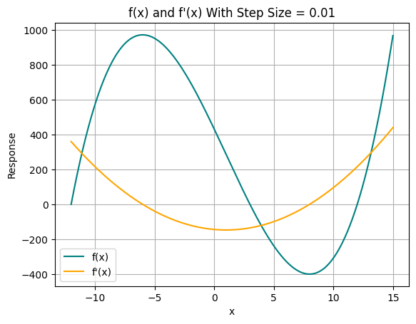

```python
h = 0.01
x = np.arange(-12, 15, h)

plt.plot(x, f(x), c='teal', label='f(x)')
plt.plot(x, f_prime(x), c='orange', label='f\'(x)')
plt.xlabel('x')
plt.ylabel('Response')
plt.title('f(x) and f\'(x) With Step Size = 0.01')
plt.grid(True)
plt.legend()
plt.show()
```

#### 3) Using the numerical method given above you are now going to estimate the derivative of this

function. Make a plot for each of the h values listed below. For each plot, graph a line plot of analytical derivative solved in 2. Then in each figure, overlay the numerical approximation of the derivative using a scatter plot.

- h = 0.01
- h = 0.1
- h = 1
- h = 2

To best visualize this, slice the approximated derivative vectors when making the scatter plot.

#### 3) Numerical Method

$f'(x) \approx \frac{f(x + h) - f(x)}{h}$

```python
def numerical_diff(x, h):
    return (f(x + h) - f(x)) / h
```

#### i. Make a plot for each h value listed. For each plot, graph a line plot of the analytical derivative from 2. Then overlay the numerical approximation of the derivation using a scatterplot.

- h = 0.01
- h = 0.1
- h = 1
- h = 2

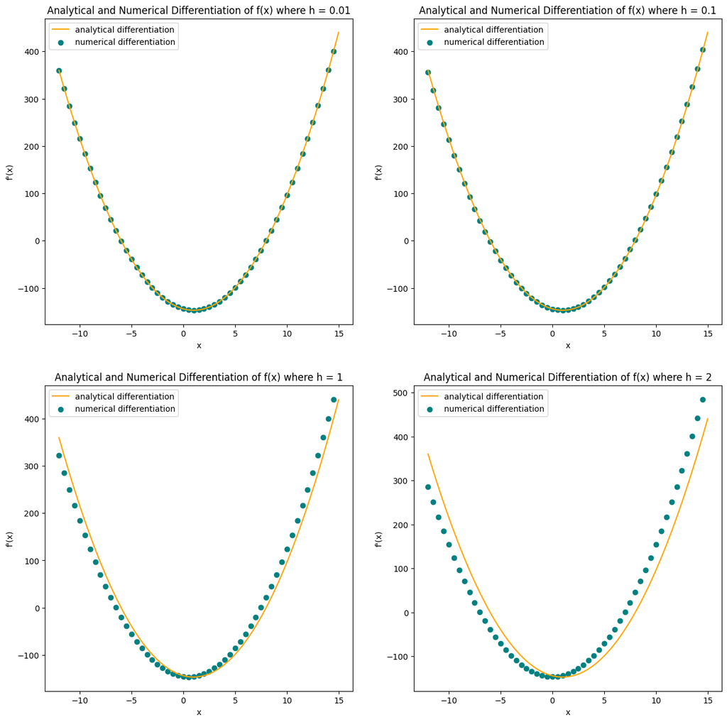

```python
hs = [0.01, 0.1, 1, 2]

fig, ax = plt.subplots(2, 2, figsize=(15, 15))

indxs = [(0,0), (0,1), (1, 0), (1, 1)]
for i, h in zip(indxs, hs):
    ax[i].plot(x, f_prime(x), c='orange', label=f'analytical differentiation')
    ax[i].scatter(x[::50], numerical_diff(x[::50], h), c='teal', label=f'numerical differentiation')
    ax[i].set_xlabel('x')
    ax[i].set_ylabel('f\'(x)')
    ax[i].set_title(f'Analytical and Numerical Differentiation of f(x) where h = {h}')
    ax[i].legend()
```

### **Experiment 2 - 1D Grid Search (Derivative Space)**

#### 1) Using your analytical solution for the derivative, solve by hand for values of x where the derivative is equal to zero. Show your work in the markdown cell.

Steps:

$f'(x) = 3x^2 - 6x - 144$

$0 = 3x^2 - 6x - 144$

$\frac{0}{3} = \frac{3x^2 - 6x - 144}{3}$

$0 = x^2 - 2x - 48$

$0 = (x + 6)(x - 8)$

$x = -6, 8$

#### 2) Using the x-values that you found, create a new figure that has a line plot of the original function and overlay the individual points of ( found_x , f(found_x) ).

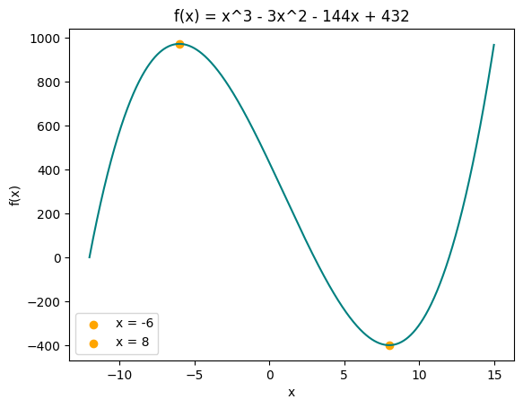

```python
roots = [-6, 8]
plt.plot(x, f(x), c='teal')
plt.scatter(roots[0], f(roots[0]), c='orange', label=f'x = {roots[0]}')
plt.scatter(roots[1], f(roots[1]), c='orange', label=f'x = {roots[1]}')
plt.title('f(x) = x^3 - 3x^2 - 144x + 432')
plt.xlabel('x')
plt.ylabel('f(x)')
plt.legend()
```

#### 3) Copy of vectors of numerical differentiation at each h value from step 3 of experiment 1.

```python
hs = [0.01, 0.1, 1, 2]
h_001 = numerical_diff(x, hs[0])
h_01 = numerical_diff(x, hs[1])
h_1 = numerical_diff(x, hs[2])
h_2 = numerical_diff(x, hs[3])
```

#### 4) Use slicing techniques to search through each of numerically approximated derivative vectors to find the 2 locations (x values) that are closest to f’(x) = 0 (derivative equal to zero)

```python
approx_001 = np.argpartition(np.absolute(h_001), kth=2)[:2]
approx_01 = np.argpartition(np.absolute(h_01), kth=2)[:2]
approx_1 = np.argpartition(np.absolute(h_1), kth=2)[:2]
approx_2 = np.argpartition(np.absolute(h_2), kth=2)[:2]

print(f'h = 0.01\tx = {x[approx_001[0]]}, {x[approx_001[1]]}\tapprox. f\'({x[approx_001[0]]}) = {h_001[approx_001[0]]} and f\'({x[approx_001[1]]}) = {h_001[approx_001[1]]}')
print(f'h = 0.1\t\tx = {x[approx_01[0]]}, {x[approx_01[1]]}\tapprox. f\'({x[approx_01[0]]}) = {h_01[approx_01[0]]} and f\'({x[approx_01[1]]}) = {h_01[approx_01[1]]}')
print(f'h = 1\t\tx = {x[approx_1[0]]}, {x[approx_1[1]]}\tapprox. f\'({x[approx_1[0]]}) = {h_1[approx_1[0]]} and f\'({x[approx_1[1]]}) = {h_1[approx_1[1]]}')
print(f'h = 2\t\tx = {x[approx_2[0]]}, {x[approx_2[1]]}\tapprox. f\'({x[approx_2[0]]}) = {h_2[approx_2[0]]} and f\'({x[approx_2[1]]}) = {h_2[approx_2[1]]}')
```

```
h = 0.01	x = -6.000000000000128, 7.989999999999576	approx. f'(-6.000000000000128) = -0.2098999999930129 and f'(7.989999999999576) = -0.20990000000438158
h = 0.1		x = 7.9499999999995765, -6.050000000000127	approx. f'(7.9499999999995765) = 0.002499999982319423 and f'(-6.050000000000127) = 0.0025000000050567905
h = 1		x = -6.4900000000001175, 7.489999999999583	approx. f'(-6.4900000000001175) = -0.16969999999503216 and f'(7.489999999999583) = -0.16970000001754215
h = 2		x = 6.979999999999595, -6.980000000000107	approx. f'(6.979999999999595) = 0.16119999998306866 and f'(-6.980000000000107) = 0.16120000000449863
```

#### 5) With these found x values, plot the original function using a line plot and place a dot over each of the found f(x) values.

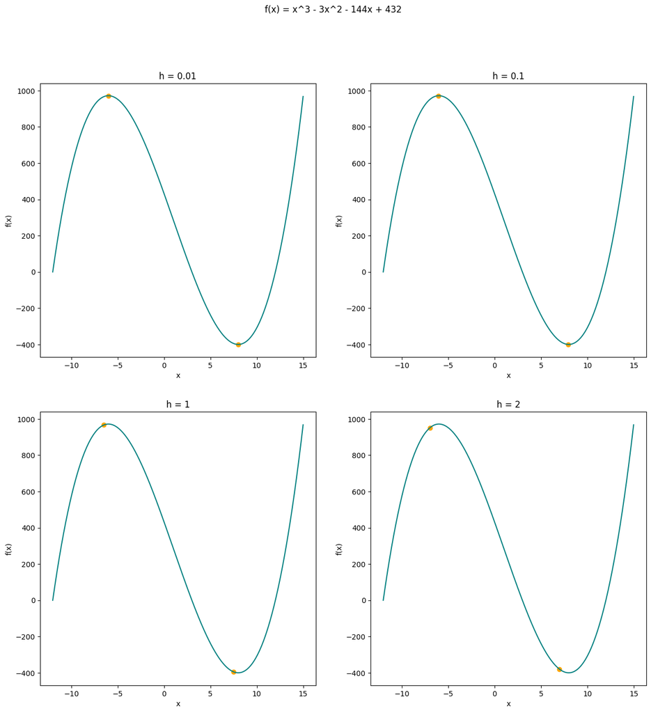

```python
fig, ax = plt.subplots(2, 2, figsize=(15, 15))
fig.suptitle('f(x) = x^3 - 3x^2 - 144x + 432')

ax[0,0].plot(x, (f(x)), c='teal')
ax[0,0].scatter(x[approx_001], f(x[approx_001]), c='orange')
ax[0,0].set_xlabel('x')
ax[0,0].set_ylabel('f(x)')
ax[0,0].set_title('h = 0.01')

ax[0,1].plot(x, (f(x)), c='teal')
ax[0,1].scatter(x[approx_01], f(x[approx_01]), c='orange')
ax[0,1].set_xlabel('x')
ax[0,1].set_ylabel('f(x)')
ax[0,1].set_title('h = 0.1')

ax[1,0].plot(x, (f(x)), c='teal')
ax[1,0].scatter(x[approx_1], f(x[approx_1]), c='orange')
ax[1,0].set_xlabel('x')
ax[1,0].set_ylabel('f(x)')
ax[1,0].set_title('h = 1')

ax[1,1].plot(x, (f(x)), c='teal')
ax[1,1].scatter(x[approx_2], f(x[approx_2]), c='orange')
ax[1,1].set_xlabel('x')
ax[1,1].set_ylabel('f(x)')
ax[1,1].set_title('h = 2')
```

#### **Experiment 3: Gaussian Model Grid Search (Derivative Space)**

#### 1) Import the cost function class that you wrote last week and load in the data from the gaussdist.csv file

```python
import cost_functions as cf

gauss_dist = np.loadtxt('./data/gaussdist.csv', delimiter=',')
x_feat = gauss_dist[:,0]
y_true = gauss_dist[:,1]

gaussian = cf.GaussianCostFunction(x_feat, y_true)
```

#### 2) Write a gradient class

```python
from numerical_differentiation import NumericalDifferentiation
```

#### 3) Perform a grid search on the model parameters like you did in lab06 experiment 2

6 ≥ $\mu$ ≥ 5

1.75 ≥ $\sigma$ ≥ 1

but this time you are searching over the derivatives (gradient) not the error. At the end of this step you should have 2 2-dimensional arrays, one for each of the model parameters. You should use a h/delta value of 1e-5.

```python
sigmas = np.linspace(1, 1.75, 50)
mus = np.linspace(5, 6, 100)

xv, yv = np.meshgrid(mus, sigmas)
parameters = np.hstack([xv.reshape(-1,1), yv.reshape(-1,1)])


nd = NumericalDifferentiation(1e-5)

gradients = np.zeros(parameters.shape)
for i in range(gradients.shape[0]):
    gradients[i] = nd.gradient(gaussian.cost, parameters[i])
```

#### 4) Generate heatmaps for each of the two derivative arrays you calculated.

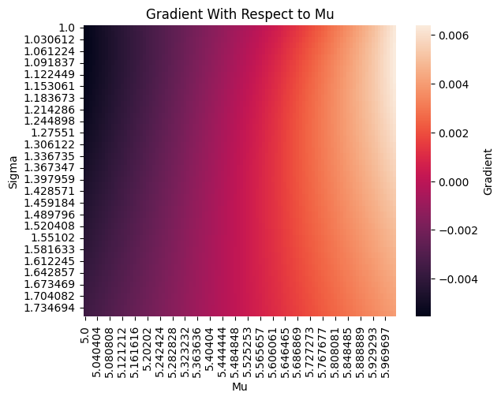

```python
sigs = np.round(sigmas, 6)
ms = np.round(mus, 6)

ax = plt.axes()

mu_gradient = gradients[:,0].reshape(xv.shape)
mu_partial_df = pd.DataFrame(data=mu_gradient, index=sigs, columns=ms)

sns.heatmap(data=mu_partial_df, ax=ax, cbar_kws={'label' : 'Gradient'})
ax.set_title('Gradient With Respect to Mu')
ax.set_xlabel('Mu')
ax.set_ylabel('Sigma')
```

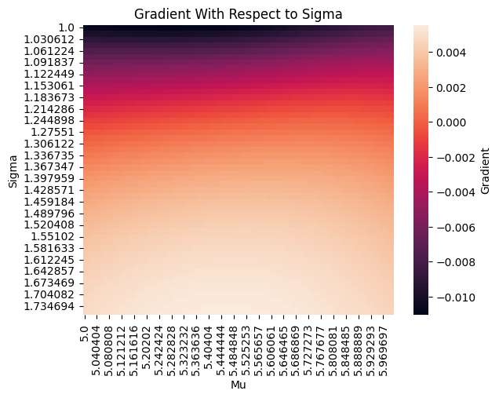

```python
ax = plt.axes()

sig_gradient = gradients[:,1].reshape(yv.shape)
sig_partial_df = pd.DataFrame(data=sig_gradient, index=sigs, columns=ms)
sns.heatmap(data=sig_partial_df, ax=ax, cbar_kws={'label' : 'Gradient'})

ax.set_title('Gradient With Respect to Sigma')
ax.set_xlabel('Mu')
ax.set_ylabel('Sigma')
```

#### 5) Find the locations in the derivative arrays that equal zero. Hint: You may have to search for the values that are closest to zero. Double Hint: If you use argsort on a 2-dimensional array, you can use array.flat() with the resulting index.

```python
mu_gradient_zero = np.argmin(np.absolute(mu_gradient.flatten()))
mu_zero = xv.flatten()[mu_gradient_zero]
grad_mu_zero = mu_gradient.flatten()[mu_gradient_zero]
print(f'mu gradient is close to zero when mu = {mu_zero}\t\tmu gradient at mu = {grad_mu_zero}')

sig_gradient_zero = np.argmin(np.absolute(sig_gradient.flatten()))
sig_zero = yv.flatten()[sig_gradient_zero]
grad_sig_zero = sig_gradient.flatten()[sig_gradient_zero]
print(f'sigma gradient is close to zero when sigma = {sig_zero}\t\tsigma gradient at sigma = {grad_sig_zero}')
```

```
mu gradient is close to zero when mu = 5.474747474747475		mu gradient at mu = 6.764060882583078e-08
sigma gradient is close to zero when sigma = 1.2908163265306123		sigma gradient at sigma = -1.3565795622255683e-07
```

#### 6) Finally, use the cost_function.predict() method with the found parameter values and plot the dataset and model output.

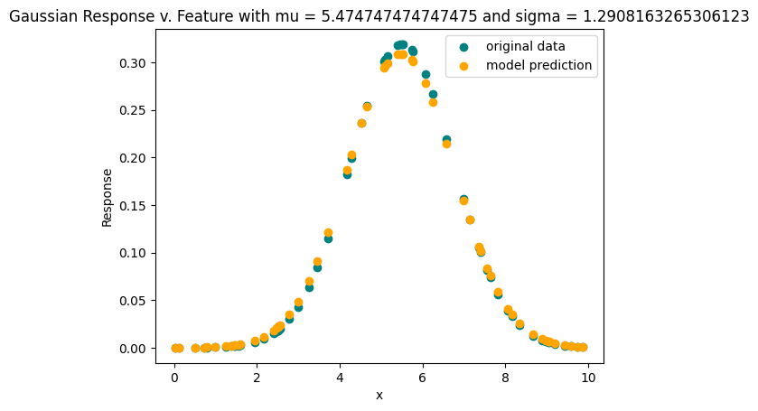

```python
y_pred = gaussian.predict(x_feat, [mu_zero, sig_zero])

plt.scatter(x_feat, y_true, c='teal', label='original data')
plt.scatter(x_feat, y_pred, c='orange', label='model prediction')
plt.title(f'Gaussian Response v. Feature with mu = {mu_zero} and sigma = {sig_zero}')
plt.xlabel('x')
plt.ylabel('Response')
plt.legend()
```